# Proyecto entrega 4

- Carolina Martínez - Enrique Tonatiuh Pérez Cortés - Eddie Aguilar - Antonio Lomelí Ureña

2024-04-19

## Introducción

El análisis de correlación entre activos financieros y el mercado es un factor fundamental cuando se habla de inversiones y las decisiones en mercados financieros. La correlación describe la relación estadística entre los movimientos de precios de diferentes activos, lo que permite comprender cómo se comportan estos activos en relación con el mercado en general. En este proyecto, se comenzará calculando la correlación del activo que se ha estado desarrollando a lo largo del semestre (FEMSA) con el mercado. Para ello, se utilizarán las técnicas estudiadas en las sesiones y se tomará el IPC como índice en representación del mercado mexicano. Posteriormente, se calculará la correlación del activo de estudio con un listado de varios activos que también cotizan en la BMV. Esto permitirá ver la relación que tiene el activo de interés con respecto de otros activos del mismo mercado y se elegirán los 5 con mayor correlación. Más adelante, se graficarán los rendimientos de FEMSA, el mercado mexicano y los 5 activos más correlacionados, para concluir con un análisis al respecto.

## Cálculo de correlación

Vamos a encontrar la correlación entre una lista de activos que cotizan en el mercado mexicano y nuestro activo de interés, la acción de *Fomento Económico Mexicano* (FEMSAUBD). También se incluye el IPC, que es representativo al comportamiento del mercado mexicano de capitales.

Primero cargamos la lista de acciones a utilizar para la comparativa. Algunas son:

```
##       EMISORA  X X.1 X.2
## 1       AC.MX NA  NA  NA
## 2 ACCELSAB.MX NA  NA  NA
## 3 ACTINVRB.MX NA  NA  NA
## 4  AEROMEX.MX NA  NA  NA
## 5     AGUA.MX NA  NA  NA
## 6  ALEATIC.MX NA  NA  NA
```

En esta parte cargamos los precios históricos de nuestro activo de interés (FEMSAUBD) y su rendimiento.

```
## [1] "FEMSAUBD.MX"
```

```
##            FEMSAUBD.MX.Adjusted
## 2007-01-03          0.001894329
## 2007-01-04         -0.007279033
## 2007-01-05         -0.008612019
## 2007-01-08          0.016284754
## 2007-01-09         -0.009580042
## 2007-01-10          0.017663221
## 2007-01-11          0.017894017
## 2007-01-12         -0.009177920
## 2007-01-15          0.026229647
## 2007-01-16         -0.014061783
##        ...
## 2024-04-05         -0.008523080
## 2024-04-08         -0.004882859
## 2024-04-09          0.005544734
## 2024-04-10         -0.024106873
## 2024-04-11         -0.001259475
## 2024-04-12          0.005076765
## 2024-04-15         -0.011349456
## 2024-04-16          0.053404115
## 2024-04-17         -0.012098599
## 2024-04-18          0.008509012
```

### Comparación con el mercado

Aquí comparamos con el mercado mexicano de valores (IPC). Juntamos los dataframes de los rendimientos de FEMSA con los rendimientos del IPC e ignoramos datos vacíos, con el fin de no alterar el cálculo de correlación.

```
## [1] "MXX"
```

```
##            FEMSAUBD.MX.Adjusted MXX.Adjusted
## 2007-01-03          0.001894329 -0.001692074
## 2007-01-04         -0.007279033 -0.001996398
## 2007-01-05         -0.008612019 -0.016344361
## 2007-01-08          0.016284754  0.005572266
## 2007-01-09         -0.009580042 -0.019153745
```

La **covarianza** y **correlación** las calculamos con funciones base de R, ya que al ser una matriz de dos activos es más simple usar este método. Después graficamos la correlación.

```
##                      FEMSAUBD.MX.Adjusted MXX.Adjusted
## FEMSAUBD.MX.Adjusted            1.0000000    0.6072047
## MXX.Adjusted                    0.6072047    1.0000000
```

```
##                      FEMSAUBD.MX.Adjusted MXX.Adjusted
## FEMSAUBD.MX.Adjusted         0.0002720361 0.0001170349
## MXX.Adjusted                 0.0001170349 0.0001365633
```

**Graficando los resultados:**

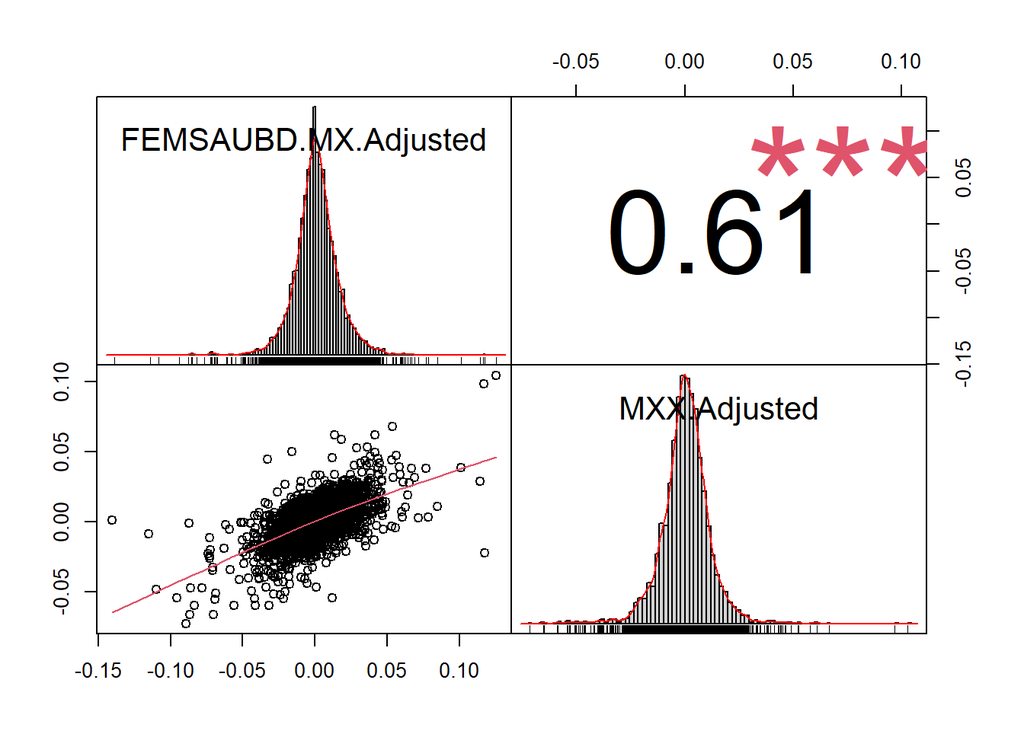

> Encontramos que:

El mercado mexicano y la acción de FEMSA se relacionan en un 60.7%. Al ser una correlación positiva y moderadamente fuerte podemos decir que los movimientos de FEMSA y el mercado mexicano se “siguen”. Esto significa que cuando al mercado le va bien, y tiene un rendimiento positivo, a la acción de FEMSA le va tambén bien y tiene un rendimiento positivo (y viceversa).

Una correlación de 0.607 es moderadamente fuerte, es probable que en cualquier día sus movimientos se sigan. Si la correlación fuera mayor a 0.9 podríamos decir que los activos están fuertemente correlacionados y sería prácticamente seguro decir que en cualquier día, si uno tiene rendimientos positivos el otro también tendrá rendimientos positivos.

Es importante conocer primero la correlación con el mercado ya que podemos comparar cómo se comporta el activo contra un agregado de valores. Una buena diversificación, es decir, si fueramos a crear un portafolio a partir de varios activos, permitiría tener una correlación más baja con el mercado, algo que sería positivo desde la perspectiva del inversionista. Para nuestro fin de analizar la acción de FEMSA es útil y positivo no tener una correlación tan alta, ya que hablamos de un activo “resistente” y posiblemente con menor riesgo sistémico.

También hay que recordar que el activo de FEMSA es más volatil que el mercado (1.65% > 1.16% en volatilidad diaria). Esto puede ser útil para tener mayores ganancias, es decir, hay una prima de riesgo por tener este activo y entendiendo que tiene una correlación con el mercado de 0.61 y una beta de 0.85 (0.00011/0.0013) podría significar que el activo por sí solo ya está lo suficientemente “diversificado”, ya que es un activo que no sigue tanto los movimientos del mercado (resistente) pero atractivo para los inversionistas y con oportunidades de generar ganancias (por su volatilidad).

Estas asumciones se deben analizar más adelante, al compararlos contra otros activos.

### Correlación

Ahora pasamos a encontrar la correlación entre nuestro activo y cada uno de los activos de la lista de emisoras, cargados desde excel en la primera sección del proyecto.

Primero descargamos los datos históricos individualmente, usando getSymbols dentro de un ciclo for, que itera sobre cada activos de la lista de emisoras. Después, todavía dentro del ciclo, calculamos la correlación entre ese activo y nuestro activo de interés. El nombre del activo y el valor de $\rho$ se cargan a una matriz, que usaremos para encontrar los 5 activos más correlacionados al nuestro.

```r
lista <- as.matrix(Emisoras)[,1]
n <- length(lista)
mat_cor_a <- matrix(nrow=n, ncol=2)
datos_cor <- new.env()
for (i in 1:n) {
  clave <- lista[i]
  getSymbols(clave, env=datos_cor, warnings = FALSE)
  precio2 <- datos_cor[[clave]][,6]
  rendimiento2 <- na.omit(diff(log(na.omit(precio2))))
  datos_cor2 <- na.omit(merge.xts(Rend, rendimiento2))
  ro <- as.numeric(cor(datos_cor2)[1,2])
  mat_cor_a[i,2] <- ro
  mat_cor_a[i,1] <- clave
}
```

Damos forma y ordenamos la matriz de correlación:

```
##            Activo                   Ro
## 1       MONEXB.MX -0.00410487593402124
## 2      CONVERA.MX -0.00738310795394446
## 3      CIDMEGA.MX -0.00802319395439177
## 4     ACCELSAB.MX  -0.0101018414877792
## 5     RCENTROA.MX  -0.0144097239013963
## 6             GNP  -0.0172855407623194
## 7      GPROFUT.MX  -0.0188893065629109
## 8         FRES.MX  -0.0419110543190686
## 9         CMRB.MX 0.000560364469985065
## 10       VINTE.MX 0.000641226098867052
## 11      BAFARB.MX   0.0018094247496213
## 12    CERAMICB.MX  0.00518967951877818
## 13      MINSAB.MX  0.00713668260125846
## 14    CABLECPO.MX   0.0071630399905553
```

[output cut: 93 more lines]

Se destacan los 5 activos con mayor correlación con la acción base de este proyecto.

```
##          Activo        Ro
## 1   FEMSAUBD.MX 1.0000000
## 2           MXX 0.6072045
## 3     KOFUBL.MX 0.4148539
## 4           AMX 0.3697224
## 5   GFNORTEO.MX 0.3688286
## 6 TLEVISACPO.MX 0.3450492
## 7   CEMEXCPO.MX 0.3354175
```

> Observando los resultados:

Podemos notar que el activo más correlacionado con FEMSA es KOFUBL, esto hace demasiado sentido ya que KOFUBL no es más que una subsidiaria de FEMSA, por lo cual esperamos un comportamiento similar entre estos dos activos. Es relevante destacar que no llega a tener una correlación mayor a la que FEMSA tiene con el mercado, siendo este el más correlacionado con nuestro activo. Si bien nuestra correlación con el mercado no es tan fuerte como es el caso de otros activos y esto indica menor riesgo sistemático, sí sigue sobresaliendo a comparación de las demás correlaciones de la tabla, también denotando, en general, una correlación no tan fuerte con las acciones comparadas. Esto es normal, ya que no tiene por qué haber una acción, ni siquiera subsidiada, que se comporte completamente similar a nuestro activo con una correlación muy fuerte, sobre todo con el lapso de tiempo que tomamos en cuenta para este ejercicio.

Viendo las otras cuatro acciones con mayor correlación, vemos que se mantienen entre un 36% y 33%, denotando, de nuevo, que un activo subsidiado va a tener un notorio aumento en su correlación a comparación de los demás activos, donde sus correlaciones no tendrán tanta diferencia entre sí. Dentro de estas vemos a América Móvil, la cual no es sorpresa que sea una de las acciones con mayor correlación, ya que es el activo con mayor market cap de Grupo BMV, haciendo a este un peso importante para el comportamiento del mercado, lo cual se traduce en una mayor similitud con nuestro activo en cuestión.

Entre más bajamos en la lista de activos, veremos que la diferencia de correlación con nuestro activo se hace pequeña, y que deja de haber mucha importancia que lugar toma que activo debido a la poca diferencia. Tal vez sería buen ejercicio posterior, contrastar con aquellas acciones que tienen muy poca correlación para tener un análisis del Grupo BMV más completo.

## Gráfico de rendimientos activos correlacionados

```r
data <- new.env()
getSymbols(claves_top5, warnings = FALSE, env=data)
```

```
## [1] "FEMSAUBD.MX"   "MXX"           "KOFUBL.MX"     "AMX"
## [5] "GFNORTEO.MX"   "TLEVISACPO.MX" "CEMEXCPO.MX"
```

```r
lista_rend <- list()

for (i in claves_top5){
  precio <- data[[i]][,6]
  Rend <- na.omit(diff(log(na.omit(precio))))
  lista_rend[[i]] <- Rend
}

datos2 <- na.omit(merge.xts(rend_mercado, lista_rend[[1]], lista_rend[[3]], lista_rend[[4]], lista_rend[[5]], lista_rend[[6]], lista_rend[[7]]))
```

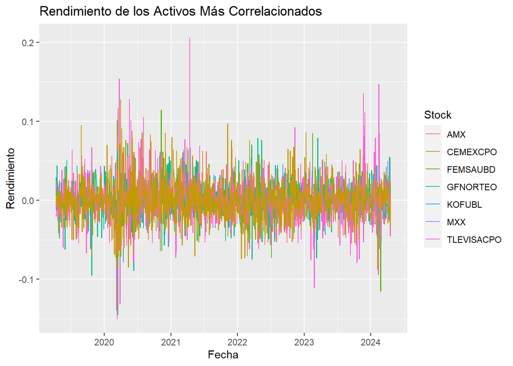

```r
datos_df <- fortify(datos2)

ggplot(data = datos_df, aes(x = Index)) +
  geom_line(aes(y = `MXX.Adjusted`, color = "MXX")) +
  geom_line(aes(y = `FEMSAUBD.MX.Adjusted`, color = "FEMSAUBD")) +
  geom_line(aes(y = `KOFUBL.MX.Adjusted`, color = "KOFUBL")) +
  geom_line(aes(y = `AMX.Adjusted`, color = "AMX")) +
  geom_line(aes(y = `GFNORTEO.MX.Adjusted`, color = "GFNORTEO")) +
  geom_line(aes(y = `TLEVISACPO.MX.Adjusted`, color = "TLEVISACPO")) +
  geom_line(aes(y = `CEMEXCPO.MX.Adjusted`, color = "CEMEXCPO")) +
  labs(x = "Fecha", y = "Rendimiento", title = "Rendimiento de los Activos Más Correlacionados") +
  labs(color = "Stock") +
  theme(legend.position = "right")
```

En la gráfica podemos notar un poco más de distorsión de lo esperado. Esto se debe a que son varios activos consolidados en una misma gráfica donde no todos tienen la misma correlación, esto genera que el rendimiento de un día a otro no se vea tan claro y similar entre todos los activos. Sin embargo, a grandes razgos sí podemos notar una similitud en los rendimientos. Si comparásemos solamente dos activos, en especial el mercado que es el más correlacionado, podremos apreciar más este cambio similar en los rendimientos de ambos activos.